# Reproducible Research: Peer Assessment 1

## Loading and preprocessing the data

### 1. Load the data

```r
activity = read.csv("activity.csv")
```

## What is mean total number of steps taken per day?

### 1. Calculate the total number of steps taken per day

```r
stepsPerDay <- aggregate(steps~date, data=activity, sum, na.rm=TRUE)
```

### 2. Make a histogram of the total number of steps taken each day

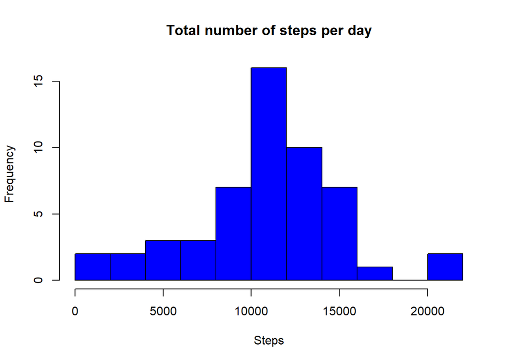

```r
hist(stepsPerDay$steps, main="Total number of steps per day", xlab="Steps", col="blue", breaks=8)
```

### 3. Calculate and report the mean and median of the total number of steps taken per day

```r
meanStepsPerDay <- mean(stepsPerDay$steps)
medianStepsPerDay <- median(stepsPerDay$steps)
```

```r
meanStepsPerDay
```

```
## [1] 10766.19
```

```r
medianStepsPerDay
```

```
## [1] 10765
```

## What is the average daily activity pattern?

### 1. Make a time series plot (i.e. type = “l”) of the 5-minute interval (x-axis) and the average number of steps taken, averaged across all days (y-axis)

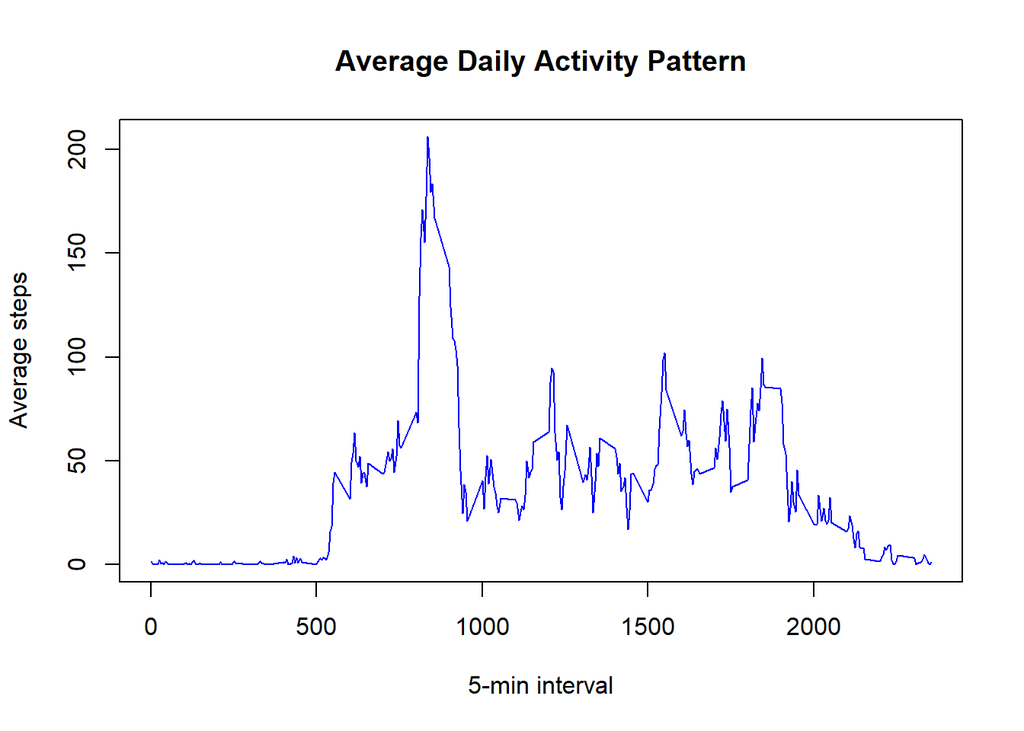

```r
stepsInterval <- aggregate(steps~interval, data=activity, mean, na.rm=TRUE)
plot(stepsInterval$interval, stepsInterval$steps, type="l", xlab="5-min interval", ylab="Average steps", main="Average Daily Activity Pattern", col="blue")
```

### 2. Which 5-minute interval, on average across all the days in the dataset, contains the maximum number of steps?

```r
stepsInterval$interval[which.max(stepsInterval$steps)]
```

```
## [1] 835
```

## Imputing missing values

### 1. Calculate and report the total number of missing values in the dataset.

```r
nrow(activity[is.na(activity$steps),])
```

```
## [1] 2304
```

### 2. Devise a strategy for filling in all of the missing values in the dataset. Create a new dataset that is equal to the original dataset but with the missing data filled in.

```r
activityWithoutNAs <- activity
activityWithoutNAs[is.na(activityWithoutNAs$steps), "steps"] <- 0
```

### 3. Make a histogram of the total number of steps taken each day.

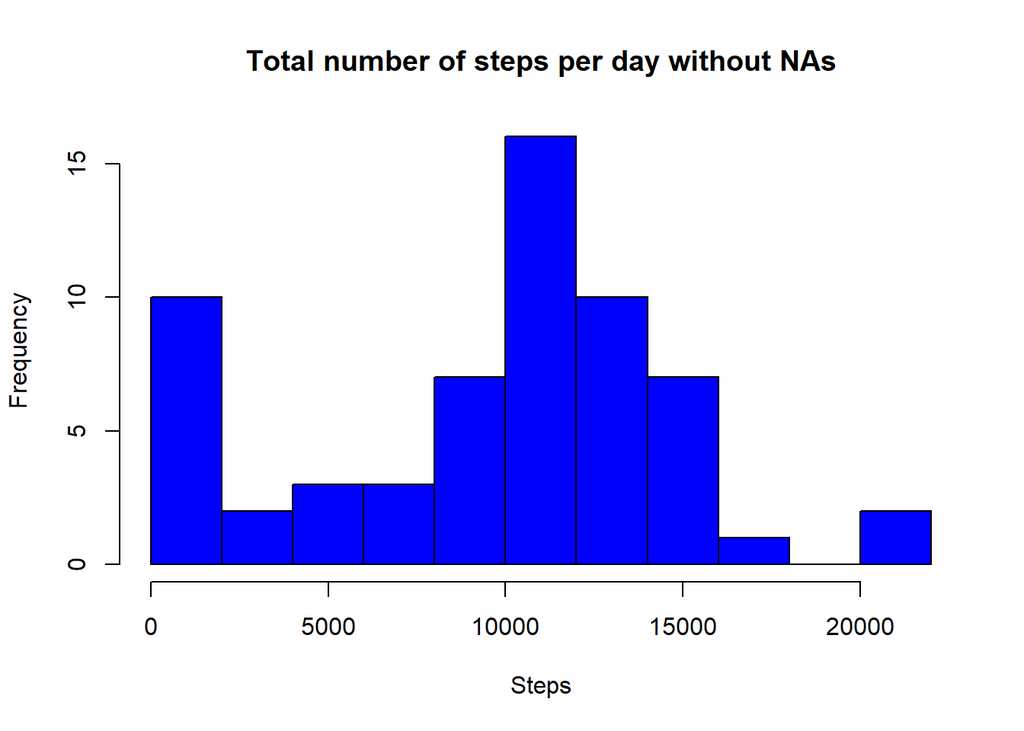

```r
stepsPerDayWithoutNAs <- aggregate(steps~date, data=activityWithoutNAs, sum, na.rm=TRUE)
hist(stepsPerDayWithoutNAs$steps, main="Total number of steps per day without NAs", xlab="Steps", col="blue", breaks=8)
```

### 4. Calculate and report the mean and median total number of steps taken per day.

```r
meanStepsPerDayWithoutNAs <- mean(stepsPerDayWithoutNAs$steps)
medianStepsPerDayWithoutNAs <- median(stepsPerDayWithoutNAs$steps)
```

```r
meanStepsPerDayWithoutNAs
```

```
## [1] 9354.23
```

```r
medianStepsPerDayWithoutNAs
```

```
## [1] 10395
```

### 5. Do these values differ from the estimates from the first part of the assignment?

Yes

### 6. What is the impact of imputing missing data on the estimates of the total daily number of steps?

Since the strategy was to change the NAs for 0 steps then the mean and median both decreased.

## Are there differences in activity patterns between weekdays and weekends?

### 1. Create a new factor variable in the dataset with two levels – “weekday” and “weekend”.

```r
activityWithoutNAs$day <- as.POSIXlt(activityWithoutNAs$date)$wday
activityWithoutNAs$dayType <- as.factor(ifelse(activityWithoutNAs$day == 0 | activityWithoutNAs$day == 6, "weekend", "weekday"))
```

```r
head(activityWithoutNAs)
```

```
##   steps       date interval day dayType
## 1     0 2012-10-01        0   1 weekday
## 2     0 2012-10-01        5   1 weekday
## 3     0 2012-10-01       10   1 weekday
## 4     0 2012-10-01       15   1 weekday
## 5     0 2012-10-01       20   1 weekday
## 6     0 2012-10-01       25   1 weekday
```

### 2. Make a panel plot containing a time series plot (i.e. type = “l”) of the 5-minute interval (x-axis) and the average number of steps taken, averaged across all weekday days or weekend days (y-axis).

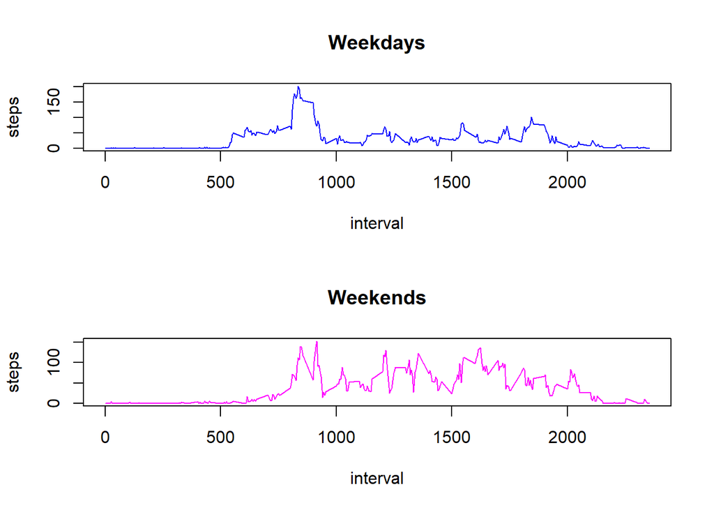

```r
weekdaysData <- activityWithoutNAs[activityWithoutNAs$dayType == "weekday",]
weekendsData <- activityWithoutNAs[activityWithoutNAs$dayType == "weekend",]
stepsIntervalWeekdays <- aggregate(steps ~ interval, weekdaysData, mean)
stepsIntervalWeekends <- aggregate(steps ~ interval, weekendsData, mean)

par(mfrow = c(2, 1))

plot(stepsIntervalWeekdays, type = "l", col = "blue", main = "Weekdays")
plot(stepsIntervalWeekends, type = "l", col = "magenta", main = "Weekends")
```